# Unidad 2 - Parte 1

### Carga de los datos

En primer lugar se establece el directorio de trabajo; también puede hacerse mediante el menú: en la parte inferior derecha de la pantalla, en la solapa “Files”“, se elige la carpeta donde se está trabajando y dentro de la opción”More“” se elije “Set as working directory”.

```r
setwd("C:/Users/gharvey/Dropbox/Facultad/Premaestria2019/4-Unidad 02 - Parte 1")
```

```r
datos=read.table(file="BASE.csv", header = TRUE, sep = ";", dec = ",", stringsAsFactors = FALSE)
```

Mediante la opción “header = TRUE” se indica que la primera fila es el nombre de cada campo; con “sep” se indica cómo están separados los valores de las distintas variables; “stringsAsFactors= FALSE” evita que se conviertan las cadenas de texto en factores directamente; mediante “dec” se indica cómo identificar al separador decimal.

```r
head(datos, 10) # Permite visualizar los primeros 10 registros.
```

```
##    ID EDAD PESO TALLA  IMC GESTAS PARTOS_PREVIOS PRIMERIZA DIL_CERVICAL_CM
## 1   1   18   60  1.50 26.6      1              0         1               5
## 2   2   27   64  1.60 25.0      4              3         0               3
## 3   3   20   63  1.60 24.6      1              0         1               4
## 4   4   18   81  1.65 29.7      1              0         1               4
## 5   5   17   84  1.60 32.8      1              0         1               3
## 6   6   27   70  1.65 23.0      1              0         1               5
## 7   7   22   98  1.55 40.7      3              2         0               6
## 8   8   27   73  1.62 28.0      3              2         0               5
## 9   9   23  120  1.65 44.0      1              0         1               6
## 10 10   22   65  1.50 29.0      1              0         1               6
##    EDAD_GEST EDAD_GEST_2 MAL_1 MAL_2 DUR_TP_HS
## 1         38           1     1     1       4.5
## 2         40           1     2     2       5.0
## 3         38           1     2     2       6.0
## 4         40           1     3     3       8.0
## 5         37           2     1     1       9.0
## 6         41           2     2     3       6.0
## 7         41           2     2     2       5.0
## 8         39           1     1     2       5.0
## 9         39           1     3     3       7.0
## 10        41           2     2     3       5.0
```

```r
attach(datos)
```

Con el comando attach se fija “datos” como base de trabajo. Sólo se recomienda cuando sea el único conjunto de datos que sea analizará. En caso de no utilizarlo, se debe indicar a qué conjunto de datos pertenecen las variables de la siguiente forma: datos$EDAD, datos$PESO, etc.

### Tablas de frecuencias

#### Ejemplo variable nominal

##### Tabla 1.

```r
(n=length(PRIMERIZA))
```

```
## [1] 100
```

```r
(tablaFrecAbs = table(PRIMERIZA))
```

```
## PRIMERIZA
##  0  1
## 41 59
```

```r
(tablaFrecRel = tablaFrecAbs/n)
```

```
## PRIMERIZA
##    0    1
## 0.41 0.59
```

```r
(tablaFrecRelPct = (tablaFrecAbs/n)*100)
```

```
## PRIMERIZA
##  0  1
## 41 59
```

#### Ejemplo variable ordinal

Si la variable es ordinal tiene sentido calcular frecuencias acumuladas.

```r
n=length(MAL_1) # Estaría de más ya que es la misma longitud que PRIMERIZA.
(tablaFrecAbs = table(MAL_1))
```

```
## MAL_1
##  1  2  3  4
## 47 33 14  6
```

```r
tablaFrecRel = tablaFrecAbs/n
(tablaFrecRelPct = (tablaFrecAbs/n)*100)
```

```
## MAL_1
##  1  2  3  4
## 47 33 14  6
```

```r
(tablaFrecAcu = cumsum(tablaFrecAbs))
```

```
##   1   2   3   4
##  47  80  94 100
```

```r
(tablaFrecRelAcu = cumsum(tablaFrecRel))
```

```
##    1    2    3    4
## 0.47 0.80 0.94 1.00
```

### Gráfico de sectores

El gráfico básico se puede obtener mediante un simple comando:

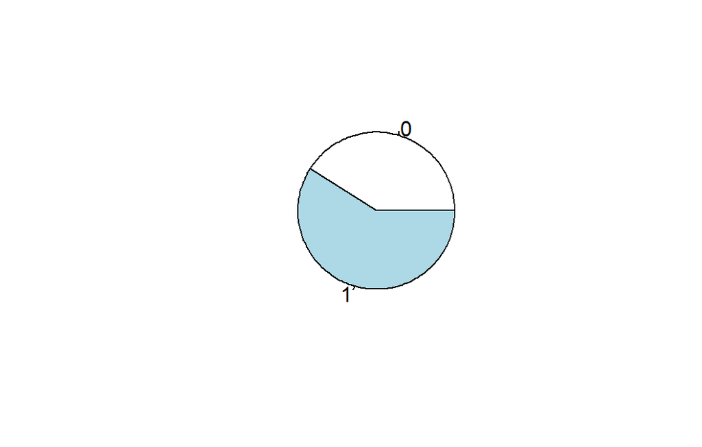

```r
pie(table(PRIMERIZA))
```

##### Figura 1.

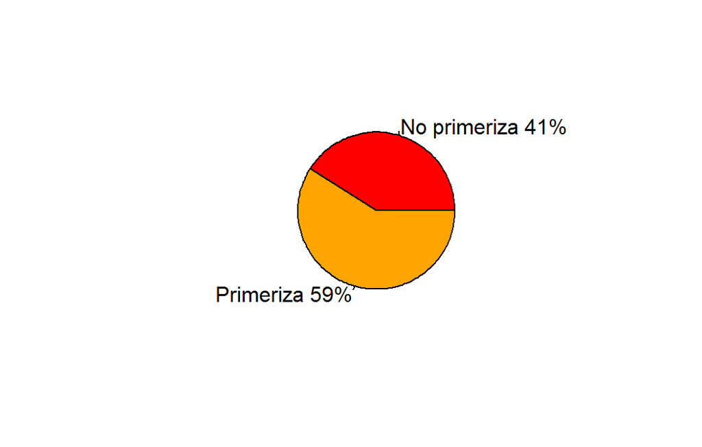

```r
frec_abs<-table(PRIMERIZA)
porcentajes<-(frec_abs/n)*100
# Si bien dado que n=100 la frecuencia absoluta coincide con el porcentaje,
# se indica en forma general.

lbls <- c("No primeriza", "Primeriza")
lbls <- paste(lbls, porcentajes) # Se agregan los % a las etiquetas
lbls <- paste(lbls,"%", sep="")  # Se agrega el sìmbolo % a las etiquetas
pie(frec_abs,labels = lbls, col=c("red", "orange"))
```

### Gráfico de barras

#### Barras verticales simples

Si quisiera un gráfico de barras horizontales usaría la opción: horiz=TRUE.

##### Figura 2.

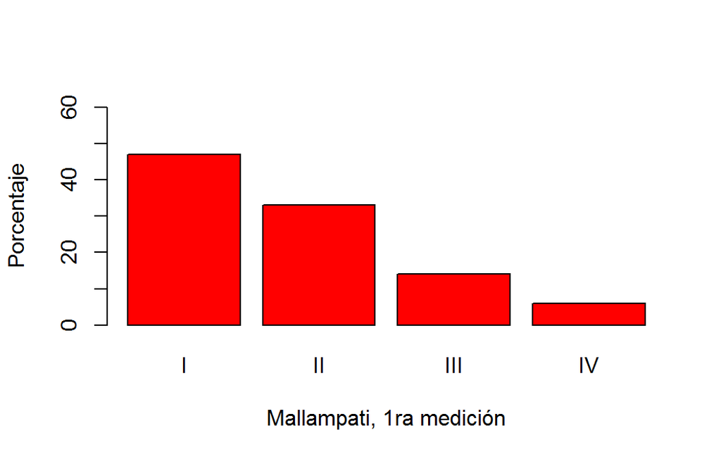

```r
barplot(tablaFrecRelPct, xlab="Mallampati, 1ra medición", ylab="Porcentaje",
        ylim=c(0,60), col=c("red"),
        names=c("I", "II", "III", "IV"))
```

#### Barras agrupadas

##### Figura 3.

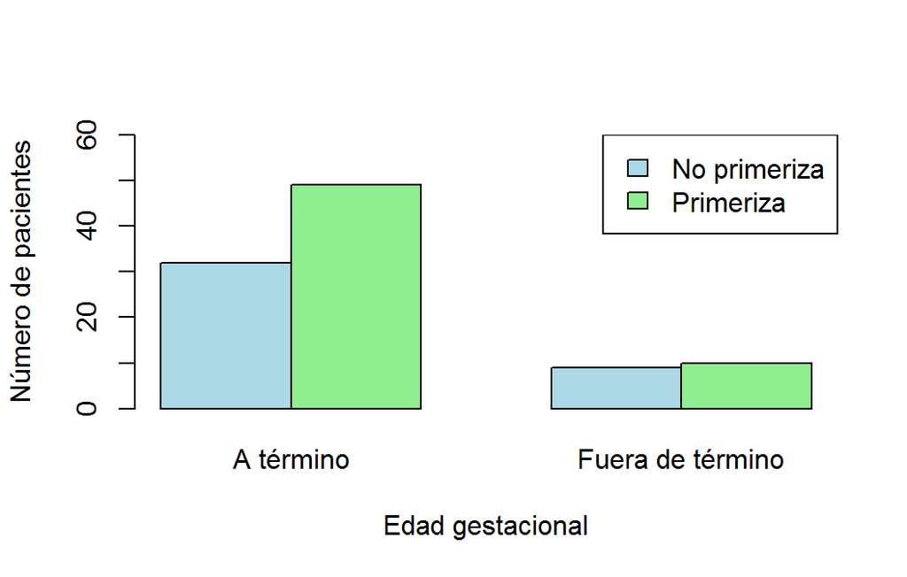

```r
counts <- table(PRIMERIZA, EDAD_GEST_2)
barplot(counts, xlab="Edad gestacional", names=c("A término", "Fuera de término"),
        ylab="Número de pacientes",
        col=c("lightblue","lightgreen"), ylim=c(0,60), beside=TRUE)

legend("topright", legend = c("No primeriza", "Primeriza"),
       fill = c("lightblue","lightgreen"))
```

### Gráfico de Pareto

Requiere el paquete “qcc” (Quality Control Charts and Statistical Process Control). Es una forma práctica de obtener la tabla de frecuencias.

```r
# install.packages("qcc")
library(qcc)
```

Tener en cuenta que se presenta sólo a modo de ejemplo ya que no sería éste el caso en el cual se recurriría a este gráfico.

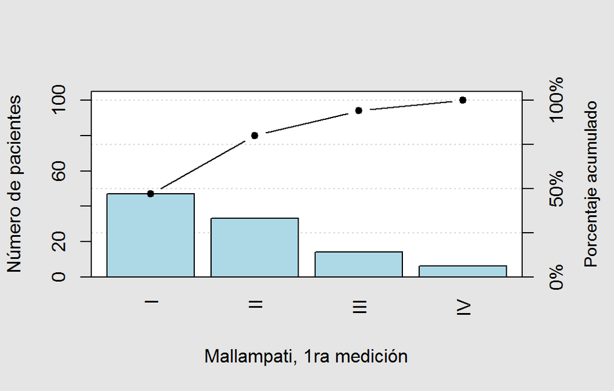

```
##
## Pareto chart analysis for frec_abs
##     Frequency Cum.Freq. Percentage Cum.Percent.
##   1        47        47         47           47
##   2        33        80         33           80
##   3        14        94         14           94
##   4         6       100          6          100
```

```r
frec_abs<-table(MAL_1)
pareto.chart(frec_abs, names=c("I", "II", "III", "IV"),
             xlab="Mallampati, 1ra medición", ylab="Número de pacientes",
             ylab2 = "Porcentaje acumulado",
             main="", col="lightblue")
```

### Diagrama de tallo y hoja

```r
stem(PESO)
```

```
##
##   The decimal point is 1 digit(s) to the right of the |
##
##    5 | 555
##    6 | 0000022233344555666888899
##    7 | 00000000000001122222233333455555556677788
##    8 | 0001122234458899
##    9 | 0002234555568
##   10 |
##   11 | 5
##   12 | 0
```

```r
stem(TALLA)
```

```
##
##   The decimal point is 1 digit(s) to the left of the |
##
##   15 | 00001224
##   15 | 55557888888999
##   16 | 0000000000001111222223333334
##   16 | 55555555555555666667777888888999
##   17 | 00000011222333
##   17 | 5555
```

### Histograma

##### Figura 4.

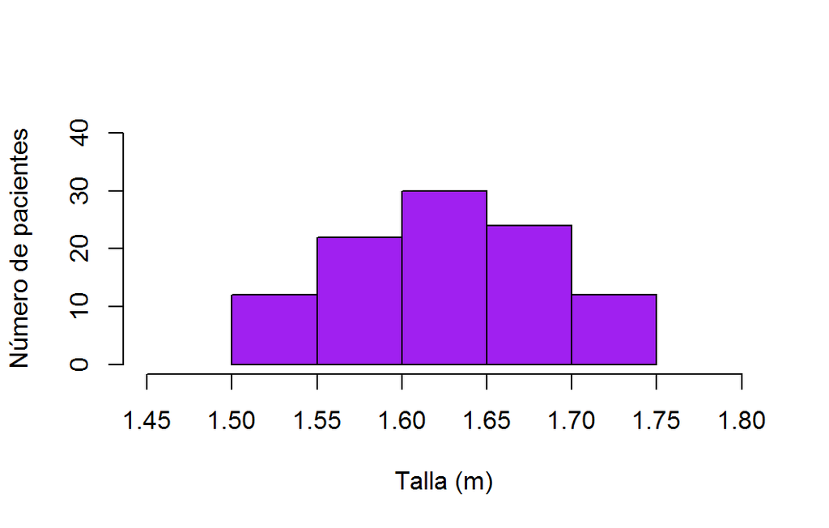

```r
hist(TALLA, main="", xlab="Talla (m)",
     ylab="Número de pacientes", ylim=c(0,40), xlim=c(1.45,1.80),
     col="purple")
```

##### Para completar Tabla 2.

Al ejecutar la sentencia con la opción “plot=F” muestra en la consola el detalle de la construcción: cuáles son los puntos de corte (breaks), la frecuencia de cada intervalo, la densidad y los puntos medios.

```r
hist(TALLA, plot=F)
```

```
## $breaks
## [1] 1.50 1.55 1.60 1.65 1.70 1.75
##
## $counts
## [1] 12 22 30 24 12
##
## $density
## [1] 2.4 4.4 6.0 4.8 2.4
##
## $mids
## [1] 1.525 1.575 1.625 1.675 1.725
##
## $xname
## [1] "TALLA"
##
## $equidist
## [1] TRUE
##
## attr(,"class")
## [1] "histogram"
```

##### Figura 5.

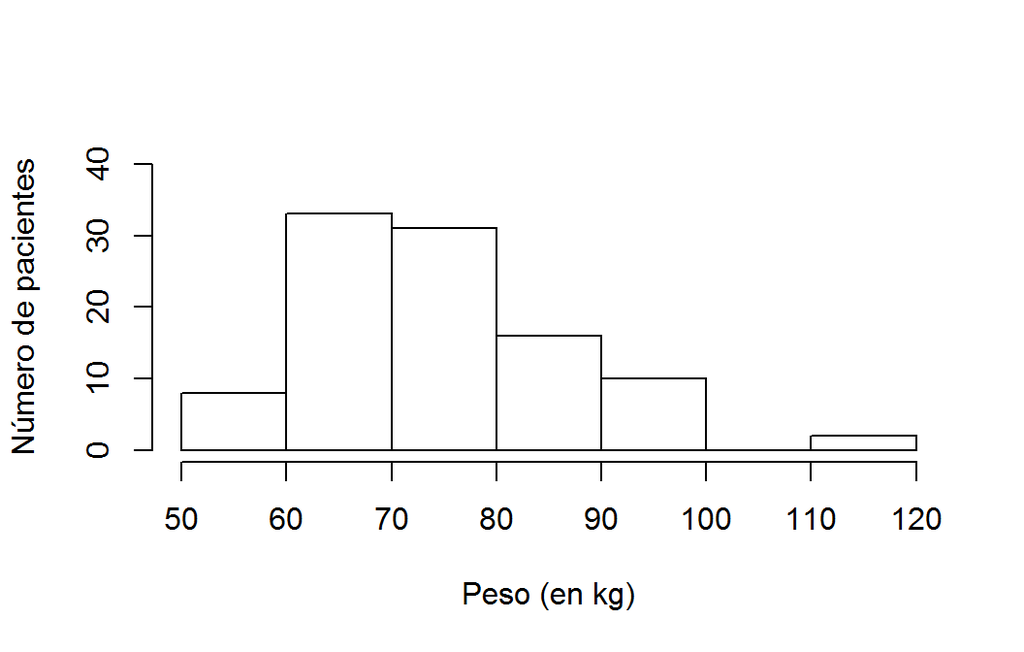

```r
hist(PESO, main="", xlab="Peso (en kg)",
     ylab="Número de pacientes", ylim=c(0,40))
```

### Medidas descriptivas

```r
mean(TALLA)
```

```
## [1] 1.6347
```

```r
mean(PESO)
```

```
## [1] 75.46
```

```r
median(TALLA)
```

```
## [1] 1.645
```

```r
median(PESO)
```

```
## [1] 73
```

```r
min(TALLA)
```

```
## [1] 1.5
```

```r
max(TALLA)
```

```
## [1] 1.75
```

```r
range(TALLA)
```

```
## [1] 1.50 1.75
```

```r
(rango<-max(TALLA)-min(TALLA))
```

```
## [1] 0.25
```

```r
var(TALLA)
```

```
## [1] 0.003742333
```

```r
sd(TALLA)
```

```
## [1] 0.06117461
```

Sólo para verificar que el valor obtenido corresponde a la fórmula presentada.

```r
dif <-TALLA-mean(TALLA)
var <-sum((dif)^2)/n
var
```

```
## [1] 0.00370491
```

```r
quantile(TALLA)
```

```
##    0%   25%   50%   75%  100%
## 1.500 1.600 1.645 1.680 1.750
```

```r
IQR(TALLA)
```

```
## [1] 0.08
```

```r
quantile(TALLA, c(0.10,0.90))
```

```
##   10%   90%
## 1.550 1.711
```

```r
summary(TALLA)
```

```
##    Min. 1st Qu.  Median    Mean 3rd Qu.    Max.
##   1.500   1.600   1.645   1.635   1.680   1.750
```

### Boxplots

#### Boxplots simples

##### Figura 6.

```r
summary(DUR_TP_HS)
```

```
##    Min. 1st Qu.  Median    Mean 3rd Qu.    Max.
##   2.000   4.500   5.000   5.765   7.000  10.000
```

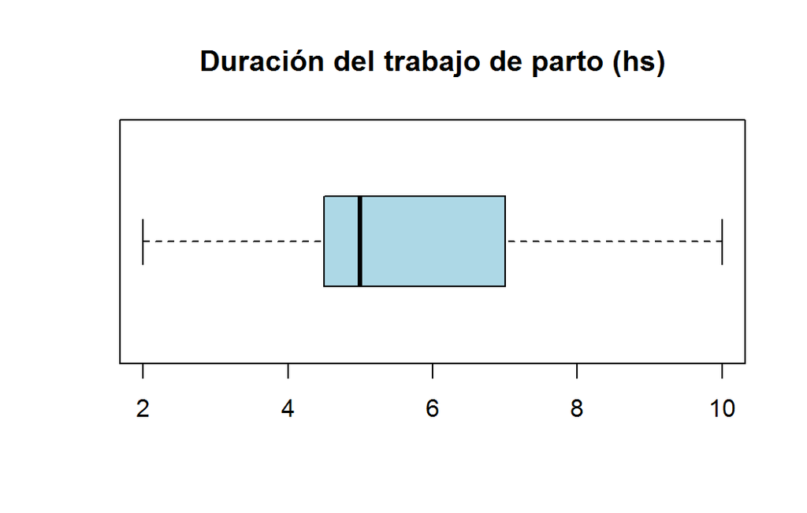

```r
boxplot(DUR_TP_HS, boxfill="lightblue", horizontal=TRUE,
        main="Duración del trabajo de parto (hs)")
```

#### Boxplots comparativos

##### Figura 7.

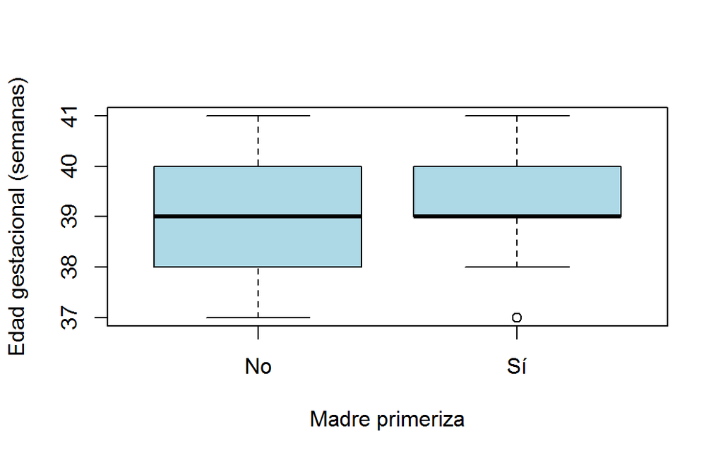

```r
boxplot(EDAD_GEST~PRIMERIZA, xlab="Madre primeriza",
        ylab="Edad gestacional (semanas)",
        names=c("No", "Sí"), boxfill="lightblue")
```

```r
detach(datos)
```